# Assignment 1

Julian Stanley

#### Top matter: Creating your own function

```r
# make a function
my.fun2 <- function(x, y) {
  a <- x^2
  b <- a + y
  return(b)
}
```

```r
# Case A
my.fun2(5, 6)
```

```
## [1] 31
```

```r
# Case B
my.fun2(6, 5)
```

```
## [1] 41
```

```r
# Case C
my.fun2(x = 5, y = 6)
```

```
## [1] 31
```

```r
# Case D
my.fun2(y = 6, x = 5)
```

```
## [1] 31
```

If the arguments are not explicitly stated, such as the case in Case A and Case B, then R assumes that the arguments are in the same order that they were initalized (in this case, x and then y). In Case D, even though the arguments are in a different order, the function call explicitly stated that y=6 and x=5.

### Exercise 1

```r
# Standard error function
sd.error <- function(x) {
  # Computers the standard error of a vector
  # Args:
  # x: The vector for which the standard deviation is being taken
  # Returns:
  # The sample standard error for the given x
  return(sd(x)/sqrt(length(x)))
}
```

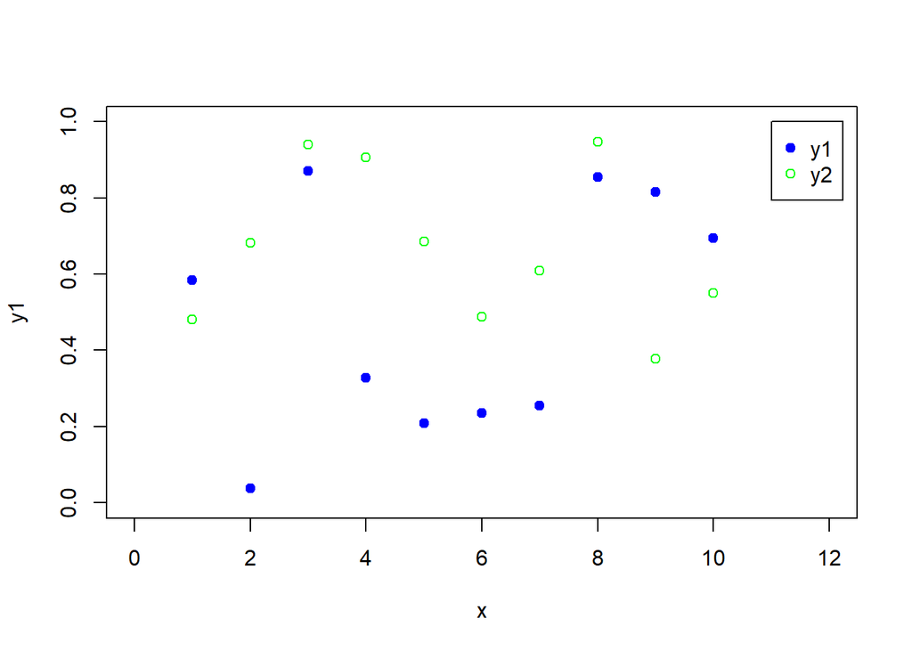

```r
# Create an explanatory variable
x <- 1:10

# Create two response variables
# runif is generating a random number between 0 and 1
y1 <- runif(10)
y2 <- runif(10)

# plot y1 on the plot
plot(x, y1, col="blue", pch = 19, xlim = c(0, 12), ylim = c(0,1))

# add y2 to the plot
points(x, y2, col= "green", pch = 1)

# Add a legend, speciy the x,y coordinates of the legend, the text of the legend, the color, and the type of points
legend(x = 11, y = 1, legend = c("y1", "y2"), col = c("blue", "green"), pch = c(19,1))
```

#### Task 1

```r
# Download the data
d1 <- read.csv("http://faraway.neu.edu/data/lab1_dataset1.csv")
```

```r
# Inspect data
str(d1)
```

```
## 'data.frame':    160 obs. of  3 variables:
##  $ sex      : Factor w/ 2 levels "female","male": 2 2 2 2 2 2 2 2 2 2 ...
##  $ treatment: Factor w/ 2 levels "drug","placebo": 2 2 2 2 2 2 2 2 2 2 ...
##  $ outcome  : Factor w/ 2 levels "not sick","sick": 2 2 2 1 2 2 1 2 2 2 ...
```

There are three factors called “sex”, “treatment”, and “outcome”, each with two levels. All three contain levels of categorical variables: {female, male}, {drug, placebo}, and {not sick, sick}.

```r
# Create a contingency table
table(d1)
```

```
## , , outcome = not sick
##
##         treatment
## sex      drug placebo
##   female   36      35
##   male     27       4
##
## , , outcome = sick
##
##         treatment
## sex      drug placebo
##   female    4       5
##   male     13      36
```

(36/40) women treated with the drug were not sick, although nearly just as many (35/40) treated with a placebo were also not sick.

(27/40) men treated with the drug were not sick, whereas much fewer men (4/40) treated with just th placebo were not sick.

On the surface, it appears that this drug is effective in the male population, but no more effective than control in the female population.